# What Teachers Value About Online PD

February 9, 2021

## Questions

1. What aspects of online professional learning resources do teachers find most valuable?
2. How might online learning resources differ in the value they afford teachers?

## Methods

**Data Source**: Items pertaining educator role, resource type, and value of resource on RttT Online Resources Survey

**Data Processing**: Tokenized and tidied text

**Data Analysis**: Word Counts & Term Frequency-Inverse Document Frequency

## Findings

## Words Used to Describe Benefits

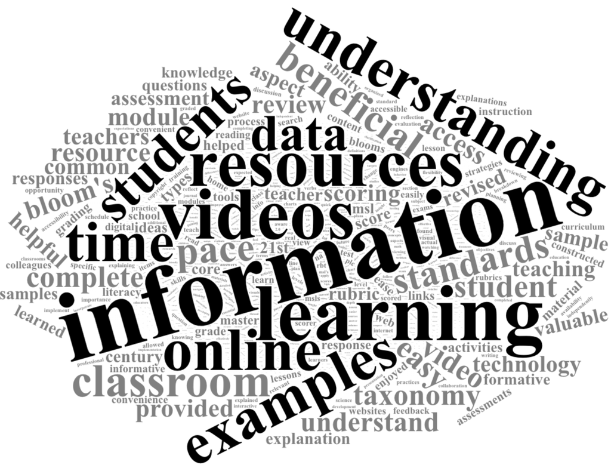

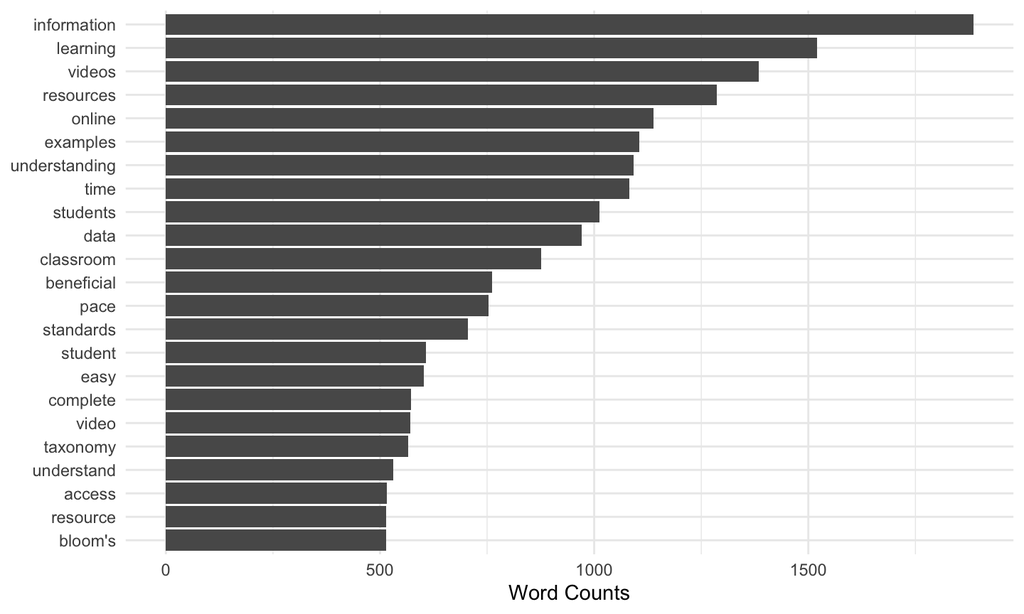

## Information Shared

“It could be completed at home in my free time. It had lots of good information that helped me understand the **terminology**.”

“the information about the way our **common core** was created for our system”

“Informative information on the **21st century learner** and teacher.”

“The most beneficial aspect was the information about **types of data** and where we get it from.”

“This has already been implemented; I do not need to know this information at this point.”

## Videos and Resource Provided

“All the videos and resources”

“**Printable resources** to keep on hand and example videos of how to use formative assessments in the classroom.”

“I was able to see other **lesson plans** and resources that other schools are doing.”

“Viewing **teacher videos**, especially Dan Meyer and Finland classroom. I was also introduced to new online resources that will aid my students and me in learning.”

“This was not a beneficial resource to me as I do not teach nor will grade the MSLs for the subject areas targeted in this resource.”

## Time and Pace for Learning

“The **ability to schedule the time to work** on the module so that it does not interfere with my commitments as an educator.”

“time to **talk with peers**”

“The most valuable aspect was the time factor. This online module was my first. I did not realize I could **walk away and work on it at another time**, so this is a tremendous aspect for the online learner.”

“Teachers are **able to go back to the information at anytime** to view the information to ensure understanding of the material.”

“The **freedom** to work at my own pace.”

## Words Emphasized in Each Resource

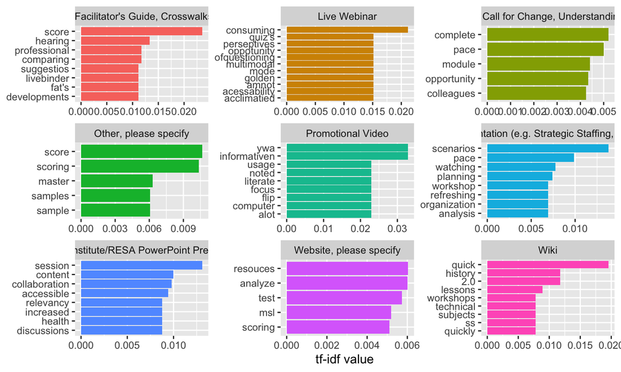

## Conclusions

1. Teachers found the **information** shared beneficial, such as new terminology, the common core standards, and types of data.
2. Teachers appreciated the **resources and videos** provided including lesson plans and printable materials.
3. Use of words like time, pace, and format suggests teachers valued the **convenience** of online professional development.

## Discussion

- **Limitations**: While able to provide quick insight into a large number of responses, analysis raised as many questions as it answered.
- **Implications**: Validation of design decisions such use of videos and inclusion of practical resources.
- **Next Steps for Analysis**: Dig into recommendations for improvement.